# Analyse en Composantes Principales

Jeu de données pca_data

Ce jeu de données contient 18944 individus et 33 variables.

### 1. Observation d’individus extrêmes

L’analyse des graphes ne révèle aucun individu singulier.

### 2. Distribution de l’inertie

L’inertie des axes factoriels indique d’une part si les variables sont structurées et suggère d’autre part le nombre judicieux de composantes principales à étudier.

Les 2 premiers axes de l’ analyse expriment **69.43%** de l’inertie totale du jeu de données ; cela signifie que 69.43% de la variabilité totale du nuage des individus (ou des variables) est représentée dans ce plan. C’est un pourcentage assez important, et le premier plan représente donc convenablement la variabilité contenue dans une grande part du jeu de données actif. Cette valeur est nettement supérieure à la valeur référence de **6.54%**, la variabilité expliquée par ce plan est donc hautement significative (cette intertie de référence est le quantile 0.95-quantile de la distribution des pourcentages d’inertie obtenue en simulant 101 jeux de données aléatoires de dimensions comparables sur la base d’une distribution normale).

Du fait de ces observations, il serait tout de même probablement préférable de considérer également dans l’analyse les dimensions supérieures ou égales à la troisième.

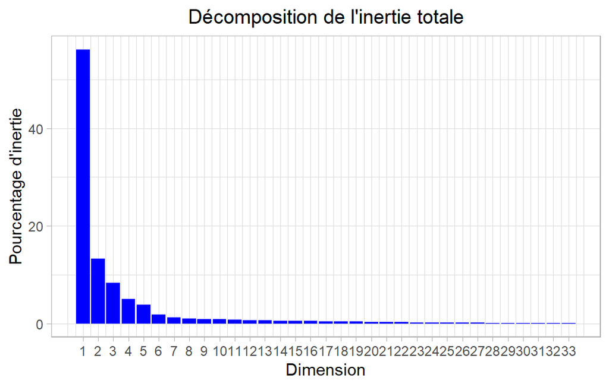

**Figure 2 - Décomposition de l’inertie totale** *Le premier facteur est prépondérant : il explique a lui seul 56.16% de la variabilité totale des données.* *Il convient de noter que dans un tel cas, la variabilité liée aux autres composantes peut être dénuée de sens, en dépit d’un pourcentage élevé.*

Une estimation du nombre pertinent d’axes à interpréter suggère de restreindre l’analyse à la description des 5 premiers axes. Ces composantes révèlent un taux d’inertie supérieur à celle du quantile 0.95-quantile de distributions aléatoires (86.52% contre 16.17%). Cette observation suggère que seuls ces axes sont porteurs d’une véritable information. En conséquence, la description de l’analyse sera restreinte à ces seuls axes.

### 3. Description du plan 1:2

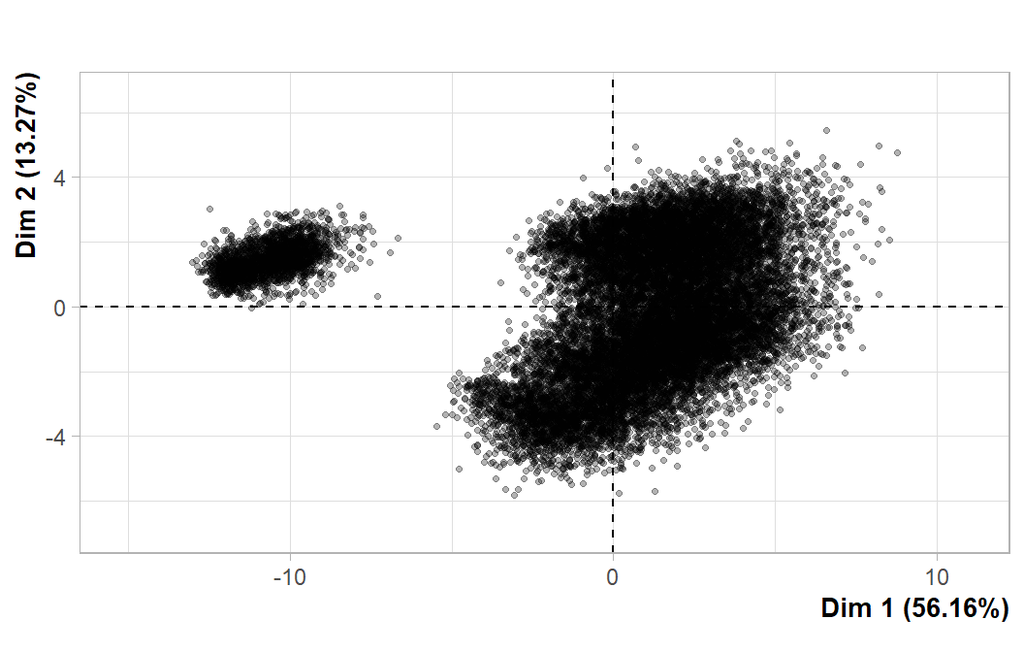

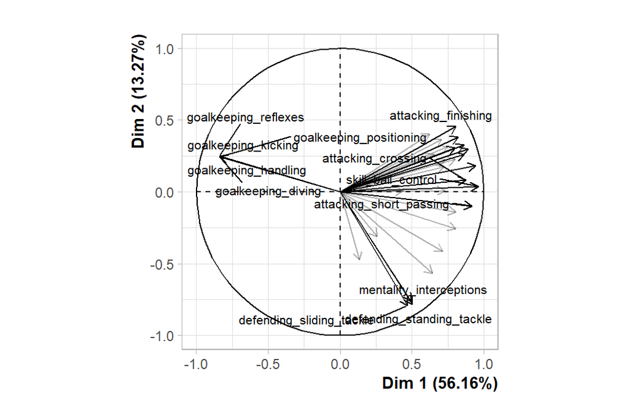

**Figure 3.2 - Graphe des variables (ACP)** *Les variables libellées sont celles les mieux représentées sur le plan.*

La **dimension 1** oppose des individus caractérisés par une coordonnée fortement positive sur l’axe (à droite du graphe) à des individus caractérisés par une coordonnée fortement négative sur l’axe (à gauche du graphe).

Le groupe 1 (caractérisés par une coordonnée positive sur l’axe) partage :

- de fortes valeurs pour des variables telles que *power_long_shots*, *attacking_finishing*, *mentality_positioning*, *skill_curve*, *attacking_volleys*, *skill_dribbling*, *skill_fk_accuracy*, *attacking_crossing*, *power_shot_power* et *mentality_vision* (de la plus extrême à la moins extrême).
- de faibles valeurs pour les variables *goalkeeping_diving*, *goalkeeping_reflexes*, *goalkeeping_handling*, *goalkeeping_positioning*, *goalkeeping_kicking* et *power_strength* (de la plus extrême à la moins extrême).

Le groupe 2 (caractérisés par une coordonnées négative sur l’axe) partage :

- de fortes valeurs pour les variables *goalkeeping_diving*, *goalkeeping_handling*, *goalkeeping_reflexes*, *goalkeeping_kicking* et *goalkeeping_positioning* (de la plus extrême à la moins extrême).
- de faibles valeurs pour des variables telles que *attacking_heading_accuracy*, *skill_ball_control*, *power_stamina*, *attacking_short_passing*, *skill_dribbling*, *mentality_aggression*, *attacking_crossing*, *skill_long_passing*, *mentality_positioning* et *movement_sprint_speed* (de la plus extrême à la moins extrême).

Le groupe 3 (caractérisés par une coordonnées négative sur l’axe) partage :

- de fortes valeurs pour les variables *defending_sliding_tackle*, *defending_standing_tackle*, *power_strength*, *mentality_interceptions*, *attacking_heading_accuracy*, *mentality_aggression*, *power_jumping* et *power_stamina* (de la plus extrême à la moins extrême).
- de faibles valeurs pour des variables telles que *power_shot_power*, *mentality_vision*, *attacking_finishing*, *power_long_shots*, *skill_curve*, *attacking_volleys*, *skill_fk_accuracy*, *movement_agility*, *mentality_positioning* et *goalkeeping_kicking* (de la plus extrême à la moins extrême).

Notons que la variable *skill_ball_control* est extrêmement corrélée à cette dimension (corrélation de 0.92). Cette variable pourrait donc résumer à elle seule la dimension 1.

La **dimension 2** oppose des individus caractérisés par une coordonnée fortement positive sur l’axe (en haut du graphe) à des individus caractérisés par une coordonnée fortement négative sur l’axe (en bas du graphe).

Le groupe 1 (caractérisés par une coordonnée positive sur l’axe) partage :

- de fortes valeurs pour les variables *goalkeeping_diving*, *goalkeeping_handling*, *goalkeeping_reflexes*, *goalkeeping_kicking* et *goalkeeping_positioning* (de la plus extrême à la moins extrême).
- de faibles valeurs pour des variables telles que *attacking_heading_accuracy*, *skill_ball_control*, *power_stamina*, *attacking_short_passing*, *skill_dribbling*, *mentality_aggression*, *attacking_crossing*, *skill_long_passing*, *mentality_positioning* et *movement_sprint_speed* (de la plus extrême à la moins extrême).

Le groupe 2 (caractérisés par une coordonnée positive sur l’axe) partage :

- de fortes valeurs pour des variables telles que *power_long_shots*, *attacking_finishing*, *mentality_positioning*, *skill_curve*, *attacking_volleys*, *skill_dribbling*, *skill_fk_accuracy*, *attacking_crossing*, *power_shot_power* et *mentality_vision* (de la plus extrême à la moins extrême).
- de faibles valeurs pour les variables *goalkeeping_diving*, *goalkeeping_reflexes*, *goalkeeping_handling*, *goalkeeping_positioning*, *goalkeeping_kicking* et *power_strength* (de la plus extrême à la moins extrême).

Le groupe 3 (caractérisés par une coordonnées négative sur l’axe) partage :

- de fortes valeurs pour les variables *defending_sliding_tackle*, *defending_standing_tackle*, *power_strength*, *mentality_interceptions*, *attacking_heading_accuracy*, *mentality_aggression*, *power_jumping* et *power_stamina* (de la plus extrême à la moins extrême).
- de faibles valeurs pour des variables telles que *power_shot_power*, *mentality_vision*, *attacking_finishing*, *power_long_shots*, *skill_curve*, *attacking_volleys*, *skill_fk_accuracy*, *movement_agility*, *mentality_positioning* et *goalkeeping_kicking* (de la plus extrême à la moins extrême).

### 4. Description du plan 3:4

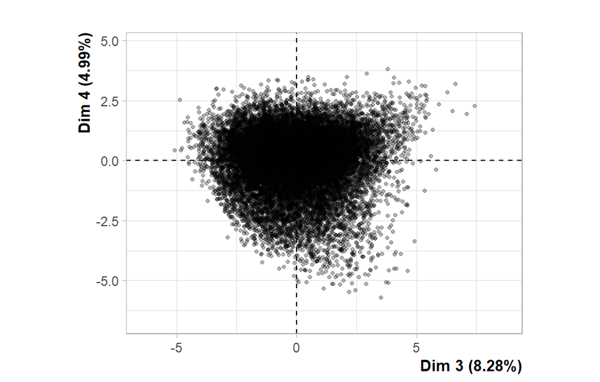

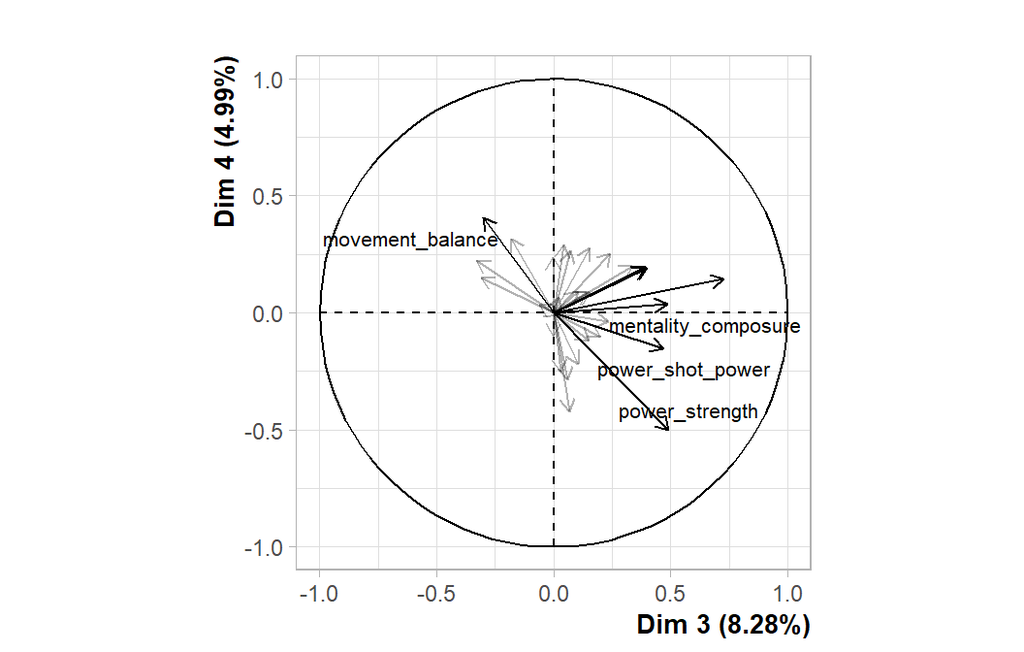

**Figure 4.2 - Graphe des variables (ACP)** *Les variables libellées sont celles les mieux représentées sur le plan.*

La **dimension 3** oppose des individus caractérisés par une coordonnée fortement positive sur l’axe (à droite du graphe) à des individus caractérisés par une coordonnée fortement négative sur l’axe (à gauche du graphe).

Le groupe 1 (caractérisés par une coordonnée positive sur l’axe) partage :

- de fortes valeurs pour des variables telles que *attacking_finishing*, *mentality_penalties*, *attacking_heading_accuracy*, *power_strength*, *attacking_volleys*, *power_shot_power*, *power_long_shots*, *mentality_positioning*, *power_jumping* et *mentality_composure* (de la plus extrême à la moins extrême).
- de faibles valeurs pour des variables telles que *defending_sliding_tackle*, *defending_standing_tackle*, *mentality_interceptions*, *movement_balance*, *attacking_crossing*, *skill_long_passing*, *movement_agility*, *movement_acceleration*, *movement_sprint_speed* et *attacking_short_passing* (de la plus extrême à la moins extrême).

Le groupe 2 (caractérisés par une coordonnée positive sur l’axe) partage :

- de fortes valeurs pour des variables telles que *movement_reactions*, *mentality_composure*, *skill_long_passing*, *mentality_vision*, *mentality_interceptions*, *attacking_short_passing*, *mentality_aggression*, *defending_standing_tackle*, *defending_sliding_tackle* et *power_shot_power* (de la plus extrême à la moins extrême).
- de faibles valeurs pour les variables *movement_sprint_speed*, *movement_acceleration*, *movement_balance* et *movement_agility* (de la plus extrême à la moins extrême).

Le groupe 3 (caractérisés par une coordonnées négative sur l’axe) partage :

- de fortes valeurs pour les variables *movement_balance*, *movement_acceleration*, *movement_sprint_speed*, *movement_agility*, *defending_sliding_tackle*, *defending_standing_tackle*, *attacking_crossing* et *mentality_interceptions* (de la plus extrême à la moins extrême).
- de faibles valeurs pour des variables telles que *power_strength*, *attacking_heading_accuracy*, *power_shot_power*, *mentality_penalties*, *power_long_shots*, *attacking_volleys*, *attacking_finishing*, *mentality_composure*, *movement_reactions* et *mentality_positioning* (de la plus extrême à la moins extrême).

La **dimension 4** oppose des individus caractérisés par une coordonnée fortement positive sur l’axe (en haut du graphe) à des individus caractérisés par une coordonnée fortement négative sur l’axe (en bas du graphe).

Le groupe 1 (caractérisés par une coordonnée positive sur l’axe) partage :

- de fortes valeurs pour les variables *movement_balance*, *movement_acceleration*, *movement_sprint_speed*, *movement_agility*, *defending_sliding_tackle*, *defending_standing_tackle*, *attacking_crossing* et *mentality_interceptions* (de la plus extrême à la moins extrême).
- de faibles valeurs pour des variables telles que *power_strength*, *attacking_heading_accuracy*, *power_shot_power*, *mentality_penalties*, *power_long_shots*, *attacking_volleys*, *attacking_finishing*, *mentality_composure*, *movement_reactions* et *mentality_positioning* (de la plus extrême à la moins extrême).

- de fortes valeurs pour des variables telles que *movement_reactions*, *mentality_composure*, *skill_long_passing*, *mentality_vision*, *mentality_interceptions*, *attacking_short_passing*, *mentality_aggression*, *defending_standing_tackle*, *defending_sliding_tackle* et *power_shot_power* (de la plus extrême à la moins extrême).
- de faibles valeurs pour les variables *movement_sprint_speed*, *movement_acceleration*, *movement_balance* et *movement_agility* (de la plus extrême à la moins extrême).

Le groupe 3 (caractérisés par une coordonnées négative sur l’axe) partage :

- de fortes valeurs pour des variables telles que *attacking_finishing*, *mentality_penalties*, *attacking_heading_accuracy*, *power_strength*, *attacking_volleys*, *power_shot_power*, *power_long_shots*, *mentality_positioning*, *power_jumping* et *mentality_composure* (de la plus extrême à la moins extrême).
- de faibles valeurs pour des variables telles que *defending_sliding_tackle*, *defending_standing_tackle*, *mentality_interceptions*, *movement_balance*, *attacking_crossing*, *skill_long_passing*, *movement_agility*, *movement_acceleration*, *movement_sprint_speed* et *attacking_short_passing* (de la plus extrême à la moins extrême).

### 5. Description de la dimension 5

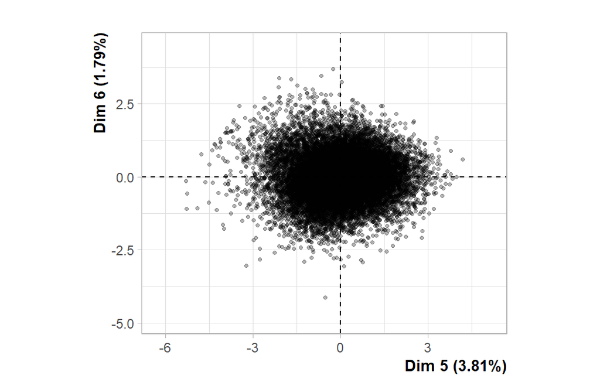

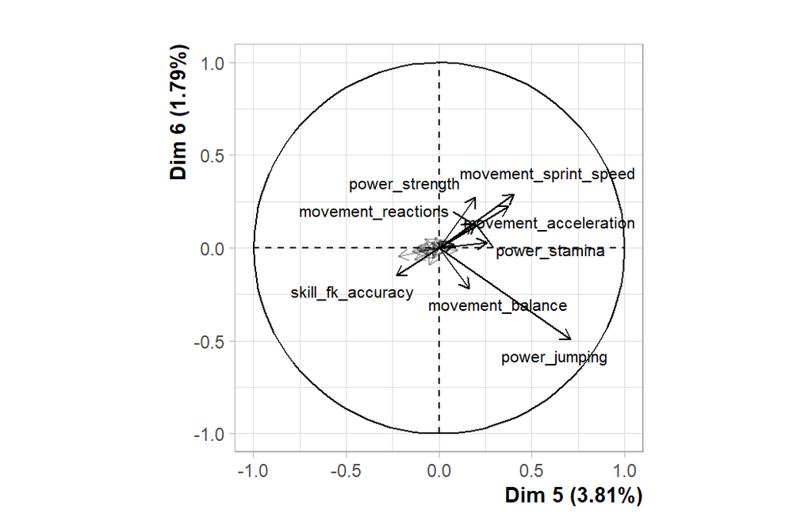

**Figure 5.2 - Graphe des variables (ACP)** *Les variables libellées sont celles les mieux représentées sur le plan.*

La **dimension 5** oppose des individus caractérisés par une coordonnée fortement positive sur l’axe (à droite du graphe) à des individus caractérisés par une coordonnée fortement négative sur l’axe (à gauche du graphe).

Le groupe 1 (caractérisés par une coordonnée positive sur l’axe) partage :

- de fortes valeurs pour des variables telles que *power_jumping*, *movement_sprint_speed*, *movement_acceleration*, *movement_agility*, *power_stamina*, *movement_balance*, *attacking_heading_accuracy*, *power_strength*, *mentality_aggression* et *movement_reactions* (de la plus extrême à la moins extrême).
- de faibles valeurs pour des variables telles que *skill_long_passing*, *skill_fk_accuracy*, *attacking_short_passing*, *mentality_vision*, *skill_curve*, *defending_standing_tackle*, *defending_sliding_tackle*, *mentality_interceptions*, *attacking_crossing* et *power_long_shots* (de la plus extrême à la moins extrême).

Le groupe 2 (caractérisés par une coordonnées négative sur l’axe) partage :

- de fortes valeurs pour des variables telles que *skill_long_passing*, *skill_fk_accuracy*, *attacking_short_passing*, *mentality_vision*, *skill_curve*, *defending_standing_tackle*, *defending_sliding_tackle*, *power_long_shots*, *mentality_penalties* et *mentality_interceptions* (de la plus extrême à la moins extrême).
- de faibles valeurs pour des variables telles que *movement_sprint_speed*, *movement_acceleration*, *power_jumping*, *power_stamina*, *movement_agility*, *power_strength*, *attacking_heading_accuracy*, *movement_reactions*, *movement_balance* et *mentality_aggression* (de la plus extrême à la moins extrême).

Le groupe 3 (caractérisés par une coordonnées négative sur l’axe) partage :

- de fortes valeurs pour les variables *movement_sprint_speed*, *movement_acceleration*, *power_strength*, *power_stamina*, *attacking_crossing*, *skill_dribbling* et *movement_reactions* (de la plus extrême à la moins extrême).
- de faibles valeurs pour des variables telles que *power_jumping*, *movement_balance*, *mentality_penalties*, *skill_fk_accuracy*, *attacking_heading_accuracy*, *power_long_shots*, *attacking_volleys*, *power_shot_power*, *skill_curve* et *mentality_aggression* (de la plus extrême à la moins extrême).

### 6. Classification

Le jeu de données est trop volumineux pour réaliser la classification.